# Vis Project Analysis

Marco Teniente

2025-11-12

## Overview

This dataset provides a comprehensive look at global income inequality from the year 2000 to 2023. It includes key indicators such as Gini index, average income, income distribution across different population percentiles, and income group classifications for 30 countries worldwide. The dataset offers insights into how income is distributed within nations and highlights disparities across different economic groups.

## Research Questions

Do Northern Regions demonstrate higher inequality for southern regions?

Which countries contain the most income disparities globally? Least?

How has the overall average income shifted throughout the years? Are there common trends for specific years?

## Data Features

Country: The name of the country.

Year: The year of the data point (2000–2023).

Population: The estimated population for the given year. Gini Index: A measure of income inequality, where 0 represents perfect equality and 1 represents maximum inequality.

Average Income (USD): The average income in USD for the country in the given year.

Top 10% Income Share (%): The percentage of total income held by the top 10% of the population.

Bottom 10% Income Share (%): The percentage of total income held by the bottom 10% of the population.

Income Group: Categorization of the country’s income group (Low Income, Lower Middle Income, Upper Middle Income, High Income).

## Loading packages

```r
pacman::p_load(tidyverse, ggplot2, highcharter, plotly, patchwork, readxl)
```

## Data Cleaning

```r
## Reading Dataset
global_income = read.csv("global_income_inequality.csv")

## Renaming variables for ease of use
global_income = global_income |>
  rename(average_income_USD = Average.Income..USD.,
         top10_income_share = Top.10..Income.Share....,
         bottom10_income_share = Bottom.10..Income.Share....,
         gini_index = Gini.Index,
         income_group = Income.Group,
         country = Country,
         year = Year,
         population = Population) |>

## grouping for time-series
  group_by(country, year) |>
  ungroup()

## Reading dataset with corresponding regions
Country_data = read_excel("Country_data.xlsx")

## Region categorization:
## EMEA (Europe, the Middle East and Africa)
## NA (North America)
## LATAM (Latin America)
## APAC (Asia-Pacific)

## Renaming and recoding variables for ease of joining.
Country_data = Country_data |>
  rename(country = Country,
         region = Region) |>
  mutate(country = recode(country,
                               "United Kingdom of Great Britain and Northern Ireland" = "United Kingdom",
                               "Russian Federation" = "Russia",
                          "United States of America" = "United States"))

## Joining both datasets into global_income.
global_income = global_income |>
  inner_join(Country_data, by = "country")
```

## Data Exploration

```r
colnames(global_income)
```

```
##  [1] "country"               "year"                  "population"
##  [4] "gini_index"            "average_income_USD"    "top10_income_share"
##  [7] "bottom10_income_share" "income_group"          "Country code"
## [10] "region"
```

```r
summary(global_income)
```

```
##    country               year        population          gini_index
##  Length:360         Min.   :2000   Min.   :  5493471   Min.   :0.2003
##  Class :character   1st Qu.:2006   1st Qu.: 78732800   1st Qu.:0.3179
##  Mode  :character   Median :2012   Median :175491272   Median :0.4296
##                     Mean   :2012   Mean   :172225063   Mean   :0.4258
##                     3rd Qu.:2017   3rd Qu.:254122453   3rd Qu.:0.5389
##                     Max.   :2023   Max.   :349176812   Max.   :0.6453
##  average_income_USD top10_income_share bottom10_income_share income_group
##  Min.   : 1031      Min.   :20.05      Min.   :1.023         Length:360
##  1st Qu.:18656      1st Qu.:30.49      1st Qu.:1.995         Class :character
##  Median :34471      Median :40.39      Median :2.976         Mode  :character
##  Mean   :35434      Mean   :40.20      Mean   :2.993
##  3rd Qu.:54260      3rd Qu.:49.92      3rd Qu.:4.025
##  Max.   :69733      Max.   :59.94      Max.   :4.986
##  Country code          region
##  Length:360         Length:360
##  Class :character   Class :character
##  Mode  :character   Mode  :character
##
##
##
```

## Comparing overall Gini Index overtime (2015 - 2023) & (2005 - 2014)

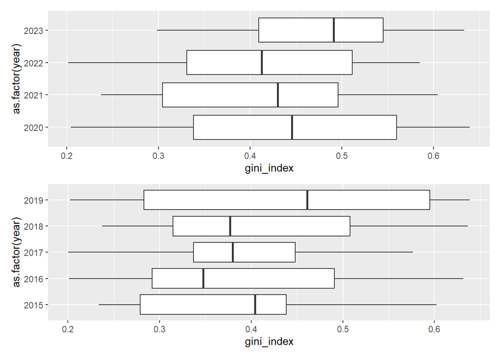

```r
c1 = global_income |>
  filter(year > 2019) |>
  group_by(year) |>
  ggplot(aes(x = as.factor(year), y = gini_index)) +
  geom_boxplot() +
  coord_flip()

c2 = global_income |>
  filter(year <= 2019, year >= 2015) |>
  group_by(year) |>
  ggplot(aes(x = as.factor(year), y = gini_index)) +
  geom_boxplot() +
  coord_flip()

c1 / c2
```

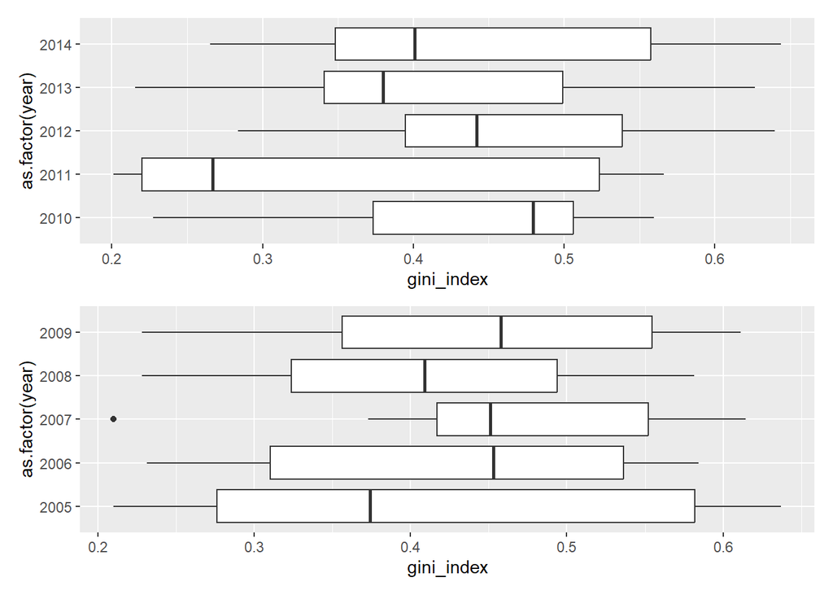

```r
c3 = global_income |>
  filter(year <= 2014, year >= 2010) |>
  group_by(year) |>
  ggplot(aes(x = as.factor(year), y = gini_index)) +
  geom_boxplot() +
  coord_flip()

c4 = global_income |>
  filter(year <= 2009, year >= 2005) |>
  group_by(year) |>
  ggplot(aes(x = as.factor(year), y = gini_index)) +
  geom_boxplot() +
  coord_flip()

c3 / c4
```

## Comparing the Gini Index Between High and Low Income Areas (Time Series)

```r
global_income |>
  group_by(year, income_group) |>
  summarize(mean_income = mean(average_income_USD),
            mean_gini = mean(gini_index), .groups = "drop") |>
  filter(income_group %in% c("High Income", "Low Income")) |>
  hchart(type = "line", hcaes(x = year, y = mean_gini, group = income_group))
```

[interactive chart not shown]

## Time Series of Avg income overtime with countries of most and least income disparities.

```r
## Pulling the top 3 and bottom 3 countries with the highest and lowest gini index.
top3_unequal = global_income |>
  filter(year %in% 2023) |>
  arrange(desc(gini_index)) |>
  head(n = 3) |>
  pull(country)

bottom3_unequal = global_income |>
  filter(year %in% 2023) |>
  arrange(gini_index) |>
  head(n = 3) |>
  pull(country)

## Plotting Time Series of Avg income overtime with countries of most income disparities.
global_income |>
  filter(country %in% top3_unequal) |>
  hchart(type = "line", hcaes(x = year, y = average_income_USD, group = country)) |>
  hc_title(text = "Average income over time by country (Most disparities)")
```

[interactive chart not shown]

```r
## Plotting Time Series of Avg income overtime with countries of least income disparities.
global_income |>
  filter(country %in% bottom3_unequal) |>
  hchart(type = "line", hcaes(x = year, y = average_income_USD, group = country)) |>
  hc_title(text = "Average income over time by country (Least disparities)")
```

[interactive chart not shown]

## Comparing Total Avg Income with Mean Gini Index for 2023

## (Grouped by Regions)

```r
global_income |>
  filter(year %in% 2023) |>
  group_by(region) |>
  summarize(avg_gini = mean(gini_index),
            avg_income = mean(average_income_USD),
            population = sum(population)) |>
  hchart(
    "bubble",
    hcaes(
      x = avg_income,
      y = avg_gini,
      group = region,
      size = population,
      name = region
    )
  ) |>
  hc_title(text = "Global Income vs Inequality in 2023") |>
  hc_xAxis(title = list(text = "Total Average Income (USD)")) |>
  hc_yAxis(title = list(text = "Average Gini Index"))
```

[interactive chart not shown]

## Gini Index in the U.S. overtime (Column Graph)

```r
global_income |>
  filter(country %in% "United States") |>

  ## Establishing threshold of 0.3 for a notably low gini_index.
  mutate(g_color = ifelse(gini_index < 0.3, "#34A853","#EA4335")) |>

hchart(type = "column", hcaes(x = year,
                              y = gini_index,
                              color = g_color))
```

[interactive chart not shown]